# my_practice_in_R

Hisanori Tanaka

2023-04-21

## Chapter01

#### 1.9 simple exercise in R

```r
rm(list = ls()) # ワークスペースをクリアにする
data01 = read.csv("../../data/data01.csv")
data01
```

```
##   x1 y1
## 1 63 63
## 2 56 66
## 3 51 61
## 4 50 60
## 5 42 52
```

```r
# head(data01)とすれば, 最初の6行ぶんを表示
```

summary関数を使って基本統計量を表示

```r
summary(data01)
```

```
##        x1             y1
##  Min.   :42.0   Min.   :52.0
##  1st Qu.:50.0   1st Qu.:60.0
##  Median :51.0   Median :61.0
##  Mean   :52.4   Mean   :60.4
##  3rd Qu.:56.0   3rd Qu.:63.0
##  Max.   :63.0   Max.   :66.0
```

## Chapter02 潜在的結果変数の枠組み

#### 2.1 潜在的結果変数の枠組み：具体例

単純な「前後比較」や「集団ごとの平均の差の比較」によって因果を推し測ろうとすることはよくある誤り.  
統計的因果推論では, 潜在的結果の差から計算される因果効果を推定する. （ただし, 実際に潜在的結果は観測されないことに注意. ）

#### 2.2 潜在的結果変数の枠組み：理論

```r
rm(list = ls())
data02 = read.csv("../../data/data02.csv")
attach(data02)
head(data02)
```

```
##   x1 y3 t1 y0 y1 y0t y1t
## 1 74 76  1 NA 76  68  76
## 2 82 75  0 75 NA  75  84
## 3 72 75  1 NA 75  65  75
## 4 96 84  0 84 NA  84  97
## 5 83 75  0 75 NA  75  84
## 6 72 74  1 NA 74  65  74
```

```r
summary(data02)
```

```
##        x1              y3             t1            y0              y1
##  Min.   :58.00   Min.   :61.0   Min.   :0.0   Min.   :72.00   Min.   :61.00
##  1st Qu.:76.25   1st Qu.:75.0   1st Qu.:0.0   1st Qu.:75.00   1st Qu.:74.25
##  Median :83.50   Median :76.5   Median :0.0   Median :77.00   Median :75.50
##  Mean   :81.95   Mean   :76.6   Mean   :0.3   Mean   :77.79   Mean   :73.83
##  3rd Qu.:87.25   3rd Qu.:80.0   3rd Qu.:1.0   3rd Qu.:80.00   3rd Qu.:76.75
##  Max.   :96.00   Max.   :87.0   Max.   :1.0   Max.   :87.00   Max.   :80.00
##                                               NA's   :6       NA's   :14
##       y0t            y1t
##  Min.   :52.0   Min.   :61.00
##  1st Qu.:69.5   1st Qu.:79.25
##  Median :75.0   Median :84.50
##  Mean   :73.8   Mean   :83.85
##  3rd Qu.:78.5   3rd Qu.:89.00
##  Max.   :87.0   Max.   :97.00
##
```

#### 2.3 処置効果１：個体因果効果

**Def 2.3：個体因果効果（ICE: individual causal effect）**

$$\tau_{i} = \gamma_{i}(1) - \gamma_{i}(0)$$

```r
y1t - y0t
```

```
##  [1]  8  9 10 13  9  9 11 12 10 10  9 10 10  9 12 12 10  9 10  9
```

```r
y3 - x1
```

```
##  [1]   2  -7   3 -12  -8   2  -9 -10  -9   3  -8  -9   3   3 -10  -8  -8  -9  -8
## [20]  -8
```

```r
y1 - y0
```

```
##  [1] NA NA NA NA NA NA NA NA NA NA NA NA NA NA NA NA NA NA NA NA
```

潜在的結果は一方が観測された時, 他方は観測されないため, ITEは定義できても観測も推定もできない.

#### 2.4 処置効果２：平均処置効果

$$\tau_{\mathrm{ATE}} = \mathrm{E} [
\gamma_{i}(1) - \gamma_{i}(0) ] = \mathrm{E} [ \gamma_{i}(1)] -
\mathrm{E} [ \gamma_{i}(0)]$$

```r
mean(y1t) - mean(y0t)
```

```
## [1] 10.05
```

```r
mean(y3) - mean(x1)
```

```
## [1] -5.35
```

```r
m1 = mean(y1, na.rm = TRUE)
m0 = mean(y0, na.rm = TRUE)
m1 - m0
```

```
## [1] -3.952381
```

#### 2.5 処置効果３：処置群の平均処置効果

**Def 2.5：処置群の平均処置効果（ATT: average treatment effect on the treated）**

$$\tau_{\mathrm{ATT}} = \mathrm{E} [
\gamma_{i}(1) - \gamma_{i}(0) | T_{i} = 1] = \mathrm{E} [ \gamma_{i}(1)
| T_{i} = 1] - \mathrm{E} [ \gamma_{i}(0) | T_{i} = 1]$$

```r
# 真のATT
mt1 = mean(y1t[t1 = 1])
mt0 = mean(y0t[t1 = 1])
mt1 - mt0
```

```
## [1] 8
```

処置が無作為である $\Rightarrow$ ATE $=$ ATT  
処置が無作為でない $\Rightarrow$ ATE $\neq$ ATT となる可能性がある

#### 2.6 交絡因子

単純な推定量にはほとんどの場合何らかの変数による交絡（confounding）がある. 統計的因果推論では, 処置の割付けがどのように行われているのかは非常に重要である.

##### 2.6.2 方向付き非巡回グラフ（DAG）

因果関係や交絡の有無を視覚化する方法として, 方向付き非巡回グラフ（DAG: Directed Acyclic Graph）というものがある.

#### 2.7 無作為抽出と無作為割付け

**Def 2.7：無作為割付け**

無作為割付けとは, 標本データを処置群と統制群に無作為に分けることである

無作為抽出の割付Ver.と考えればよい.

また, 処置群と統制群に無作為割付けする研究方法を実験研究, そうでない研究方法を観察研究と呼ぶ.

#### 2.8 無作為割付けによる分析の例

```r
set.seed(1)
r0 = runif(20, 0, 1)
r1 = round(r0, 0)
y2 = NULL
y2[r1 == 1] = y1t[r1 == 1]
y2[r1 == 0] = y0t[r1 == 0]
```

```r
r1
```

```
##  [1] 0 0 1 1 0 1 1 1 1 0 0 0 1 0 1 0 1 1 0 1
```

```r
y2
```

```
##  [1] 68 75 75 97 75 74 87 89 87 70 87 75 77 52 93 72 82 89 80 87
```

```r
mr1 = mean(y2[r1 == 1])
mr0 = mean(y2[r1 == 0])
mr1 - mr0
```

```
## [1] 12.51515
```

#### 2.10 ２標本$t$検定

```r
t.test(y2[r1==1], y2[r1==0], var.equal = FALSE)
```

```
##
##  Welch Two Sample t-test
##
## data:  y2[r1 == 1] and y2[r1 == 0]
## t = 3.2178, df = 14.878, p-value = 0.005801
## alternative hypothesis: true difference in means is not equal to 0
## 95 percent confidence interval:
##   4.219264 20.811039
## sample estimates:
## mean of x mean of y
##  85.18182  72.66667
```

### Chapter03 統計的因果推論における重要な仮定

#### 3.1 STUVA

**Def 3.1：STUVA（stable unit treatment value assumption）**

SUTVAとは, 以下の2つの条件を満たすことである.

1. 相互干渉がない
2. 個体に対する隠れた処置がない

#### 3.8 共変量の役割

**Def 3.8：無交絡性（unconfoundedness）**

処置の割付けを表す変数$T_{i}$が, 潜在的結果変数の組$\{ \gamma_{i}(1), \gamma_{i}(0) \}$に依存しないことを条件付き独立または無交絡性という.
$$\{ \gamma_{i}(1), \gamma_{i}(0) \} \perp T_{i} |
\bf{X}$$

```r
rm(list = ls())
data03 = read.csv("../../data/data03.csv")
attach(data03)
head(data03)
```

```
##   x1 y3 t1 y0t y1t
## 1 70 74  1  62  74
## 2 70 63  0  63  74
## 3 70 73  1  62  73
## 4 70 71  1  65  71
## 5 70 74  1  63  74
## 6 75 67  0  67  77
```

```r
summary(data03)
```

```
##        x1              y3              t1           y0t             y1t
##  Min.   :70.00   Min.   :63.00   Min.   :0.0   Min.   :62.00   Min.   :71.00
##  1st Qu.:73.75   1st Qu.:73.75   1st Qu.:0.0   1st Qu.:66.50   1st Qu.:75.50
##  Median :80.00   Median :77.00   Median :0.5   Median :71.00   Median :81.50
##  Mean   :80.00   Mean   :77.25   Mean   :0.5   Mean   :72.20   Mean   :82.00
##  3rd Qu.:86.25   3rd Qu.:82.00   3rd Qu.:1.0   3rd Qu.:78.75   3rd Qu.:88.75
##  Max.   :90.00   Max.   :91.00   Max.   :1.0   Max.   :82.00   Max.   :92.00
```

```r
mean(y3[t1==1]) - mean(y3[t1==0])
```

```
## [1] 3.3
```

```r
mean(y1t) - mean(y0t)
```

```
## [1] 9.8
```

「無視可能な割付け」とは, ナイーブな推定量によって文字通りに「割付けを無視して解析してよい」ということを意味するわけではない.

### Chapter05 回帰分析の基礎

#### 5.2 数値例で理解する最小二乗法

```r
rm(list = ls())
y1 = c(40, 20, 50, 10)
x1 = c(5, 1, 3, 2)
```

```r
yhat1 = 11.143 + 6.857 * x1
e1 = y1 - yhat1
print(yhat1)
```

```
## [1] 45.428 18.000 31.714 24.857
```

```r
print(e1)
```

```
## [1]  -5.428   2.000  18.286 -14.857
```

```r
yhat2 = 10.909 * x1
e2 = y1 - yhat2
print(yhat2)
```

```
## [1] 54.545 10.909 32.727 21.818
```

```r
print(e2)
```

```
## [1] -14.545   9.091  17.273 -11.818
```

```r
# 残差の合計は常にゼロである（以下の例では, 丸め誤差のためにゼロにはなっていない）
sum(e1)
```

```
## [1] 0.001
```

```r
sum(e2)
```

```
## [1] 0.001
```

```r
sum(e1^2)
```

```
## [1] 588.5714
```

```r
sum(e2^2)
```

```
## [1] 732.225
```

```r
model1 = lm(y1 ~ x1)
summary(model1)
```

```
##
## Call:
## lm(formula = y1 ~ x1)
##
## Residuals:
##       1       2       3       4
##  -5.429   2.000  18.286 -14.857
##
## Coefficients:
##             Estimate Std. Error t value Pr(>|t|)
## (Intercept)   11.143     18.109   0.615    0.601
## x1             6.857      5.799   1.182    0.359
##
## Residual standard error: 17.15 on 2 degrees of freedom
## Multiple R-squared:  0.4114, Adjusted R-squared:  0.1171
## F-statistic: 1.398 on 1 and 2 DF,  p-value: 0.3586
```

#### 5.4 条件付き期待値としての回帰モデル

```r
rm(list = ls())
y1 = c(seq(9))
x1 = c(rep(1, 3), rep(2, 3), rep(3, 3))
mean(y1)
```

```
## [1] 5
```

```r
model2 = lm(y1 ~ x1)
summary(model2)
```

```
##
## Call:
## lm(formula = y1 ~ x1)
##
## Residuals:
##    Min     1Q Median     3Q    Max
##     -1     -1      0      1      1
##
## Coefficients:
##             Estimate Std. Error t value Pr(>|t|)
## (Intercept)  -1.0000     0.8165  -1.225     0.26
## x1            3.0000     0.3780   7.937 9.58e-05 ***
## ---
## Signif. codes:  0 '***' 0.001 '**' 0.01 '*' 0.05 '.' 0.1 ' ' 1
##
## Residual standard error: 0.9258 on 7 degrees of freedom
## Multiple R-squared:    0.9,  Adjusted R-squared:  0.8857
## F-statistic:    63 on 1 and 7 DF,  p-value: 9.585e-05
```

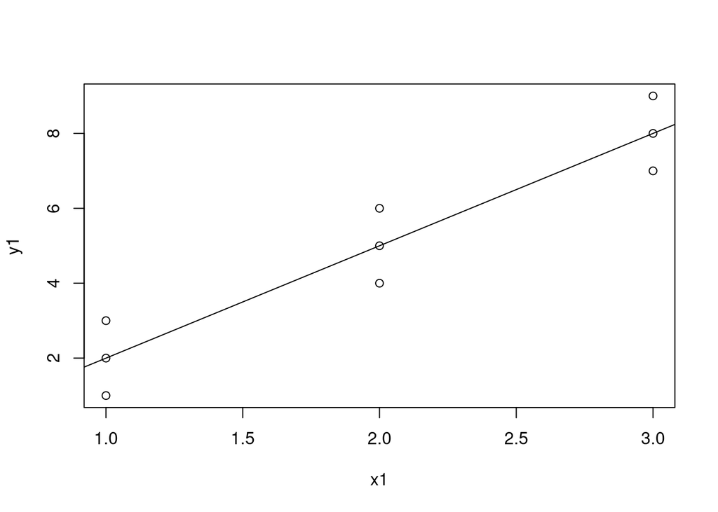

```r
plot(x1, y1)
abline(model2)
```

### Chapter06 図で理解する重回帰モデルの基礎

```r
rm(list = ls())
data06 = read.csv("../../data/data06.csv")
attach(data06)
head(data06)
```

```
##     country          y1  x1     x2
## 1 australia  3.87132550 4.9 54.763
## 2   austria 15.65853828 8.1 49.701
## 3   belgium  8.64357277 5.6 46.198
## 4    brazil  0.00000000 1.2  8.755
## 5    canada  4.17386626 4.0 46.550
## 6     china  0.02124979 0.1 10.004
```

```r
summary(data06)
```

```
##       country         y1               x1             x2
##  australia: 1   Min.   : 0.000   Min.   :0.10   Min.   : 8.755
##  austria  : 1   1st Qu.: 1.961   1st Qu.:4.00   1st Qu.:31.453
##  belgium  : 1   Median : 8.644   Median :4.90   Median :46.232
##  brazil   : 1   Mean   : 9.748   Mean   :4.87   Mean   :44.704
##  canada   : 1   3rd Qu.:13.857   3rd Qu.:6.20   3rd Qu.:53.908
##  china    : 1   Max.   :30.763   Max.   :8.80   Max.   :85.135
##  (Other)  :17
```

```r
summary(data06)
```

```
##       country         y1               x1             x2
##  australia: 1   Min.   : 0.000   Min.   :0.10   Min.   : 8.755
##  austria  : 1   1st Qu.: 1.961   1st Qu.:4.00   1st Qu.:31.453
##  belgium  : 1   Median : 8.644   Median :4.90   Median :46.232
##  brazil   : 1   Mean   : 9.748   Mean   :4.87   Mean   :44.704
##  canada   : 1   3rd Qu.:13.857   3rd Qu.:6.20   3rd Qu.:53.908
##  china    : 1   Max.   :30.763   Max.   :8.80   Max.   :85.135
##  (Other)  :17
```

### Chapter07 最小二乗法による重回帰モデルの仮定と診断１

```r
rm(list = ls())
data07a = read.csv("../../data/data07a.csv")
head(data07a)
```

```
##          y1         y2          y3          y4          x1        x2
## 1  2.075994 -0.9556782  7.97246574  0.14146850  1.13496509 0.4122400
## 2  2.851541 -1.6997390 17.31444444  0.06722305  1.11193184 0.1462768
## 3 -1.141795  2.5939225  0.31924544  4.92302168 -0.87077763 5.0515784
## 4  2.911378  3.3741857 18.38211498 10.74226176  0.21073158 1.6808001
## 5  1.433601  1.2457329  4.19377483  1.27855799  0.06939565 0.9456810
## 6 -2.314442  1.2241580  0.09882134  1.25126874 -1.66264885 2.0065516
```

#### 7.3 仮定３：誤差項の条件付き期待値ゼロ

##### 7.3.1 不要なモデルを取り入れる問題

```r
rm(list = ls())
data07c = read.csv("../../data/data07c.csv")
head(data07c)
```

```
##            y1         x1          x2         x3
## 1 -0.67395852 -0.7600421 -1.18751556  0.2094434
## 2  0.40320144 -0.2091804 -0.59289399  1.0790914
## 3  1.73275413 -0.4830352  0.05358555 -1.4506857
## 4  3.21238925  1.6794651  0.69386915  1.3529309
## 5 -0.03101438  0.3109033  0.13953087  0.3235217
## 6  1.96618931 -0.7143339  0.80131038 -1.6589480
```

```r
summary(data07c)
```

```
##        y1                x1                  x2                  x3
##  Min.   :-8.1670   Min.   :-3.013259   Min.   :-2.795193   Min.   :-3.39119
##  1st Qu.:-0.6056   1st Qu.:-0.719596   1st Qu.:-0.700067   1st Qu.:-0.68897
##  Median : 1.0544   Median :-0.009873   Median : 0.016571   Median :-0.04079
##  Mean   : 1.0114   Mean   :-0.008575   Mean   : 0.004854   Mean   :-0.02090
##  3rd Qu.: 2.7284   3rd Qu.: 0.703909   3rd Qu.: 0.707734   3rd Qu.: 0.62961
##  Max.   : 8.5708   Max.   : 4.043700   Max.   : 3.606328   Max.   : 3.65575
```

```r
model17 = lm(y1 ~ x1, data=data07c)
model18 = lm(y1 ~ x1 + x2, data=data07c)
model19 = lm(y1 ~ x1 + x2 + x3, data=data07c)
summary(model17)
```

```
##
## Call:
## lm(formula = y1 ~ x1, data = data07c)
##
## Residuals:
##     Min      1Q  Median      3Q     Max
## -5.6774 -1.0027  0.0081  0.9991  4.2545
##
## Coefficients:
##             Estimate Std. Error t value Pr(>|t|)
## (Intercept)  1.02772    0.04714   21.80   <2e-16 ***
## x1           1.90298    0.04507   42.23   <2e-16 ***
## ---
## Signif. codes:  0 '***' 0.001 '**' 0.01 '*' 0.05 '.' 0.1 ' ' 1
##
## Residual standard error: 1.491 on 998 degrees of freedom
## Multiple R-squared:  0.6412, Adjusted R-squared:  0.6408
## F-statistic:  1783 on 1 and 998 DF,  p-value: < 2.2e-16
```

```r
summary(model18)
```

```
##
## Call:
## lm(formula = y1 ~ x1 + x2, data = data07c)
##
## Residuals:
##     Min      1Q  Median      3Q     Max
## -3.2427 -0.7140 -0.0121  0.7199  3.0591
##
## Coefficients:
##             Estimate Std. Error t value Pr(>|t|)
## (Intercept)  1.01709    0.03287   30.95   <2e-16 ***
## x1           1.33356    0.03598   37.07   <2e-16 ***
## x2           1.18321    0.03641   32.50   <2e-16 ***
## ---
## Signif. codes:  0 '***' 0.001 '**' 0.01 '*' 0.05 '.' 0.1 ' ' 1
##
## Residual standard error: 1.039 on 997 degrees of freedom
## Multiple R-squared:  0.8257, Adjusted R-squared:  0.8254
## F-statistic:  2362 on 2 and 997 DF,  p-value: < 2.2e-16
```

```r
summary(model19)
```

```
##
## Call:
## lm(formula = y1 ~ x1 + x2 + x3, data = data07c)
##
## Residuals:
##     Min      1Q  Median      3Q     Max
## -3.2427 -0.7139 -0.0122  0.7199  3.0592
##
## Coefficients:
##              Estimate Std. Error t value Pr(>|t|)
## (Intercept) 1.0170949  0.0328904  30.924   <2e-16 ***
## x1          1.3332506  0.0741299  17.985   <2e-16 ***
## x2          1.1833344  0.0449052  26.352   <2e-16 ***
## x3          0.0003145  0.0661266   0.005    0.996
## ---
## Signif. codes:  0 '***' 0.001 '**' 0.01 '*' 0.05 '.' 0.1 ' ' 1
##
## Residual standard error: 1.04 on 996 degrees of freedom
## Multiple R-squared:  0.8257, Adjusted R-squared:  0.8252
## F-statistic:  1573 on 3 and 996 DF,  p-value: < 2.2e-16
```

```r
confint(model18)
```

```
##                 2.5 %   97.5 %
## (Intercept) 0.9525962 1.081587
## x1          1.2629626 1.404155
## x2          1.1117615 1.254657
```

```r
confint(model19)
```

```
##                  2.5 %    97.5 %
## (Intercept)  0.9525525 1.0816372
## x1           1.1877819 1.4787193
## x2           1.0952147 1.2714541
## x3          -0.1294489 0.1300779
```

##### 7.3.2 中間変数をモデルに取り入れる問題

```r
rm(list = ls())
data07d = read.csv("../../data/data07d.csv")
head(data07d)
```

```
##           y1         x1        x2
## 1  0.7338017 -0.6264538  1.195284
## 2  2.1813576  0.1836433  2.387397
## 3  0.1843189 -0.8356286 -1.124221
## 4  7.9175183  1.5952808  3.603653
## 5  3.2488989  0.3295078  1.563657
## 6 -1.6422130 -0.8204684 -1.893351
```

```r
summary(data07d)
```

```
##        y1                x1                 x2
##  Min.   :-8.8865   Min.   :-3.00805   Min.   :-4.8032
##  1st Qu.:-0.2536   1st Qu.:-0.69737   1st Qu.:-0.2237
##  Median : 2.2271   Median :-0.03532   Median : 0.9982
##  Mean   : 2.1597   Mean   :-0.01165   Mean   : 0.9663
##  3rd Qu.: 4.5914   3rd Qu.: 0.68843   3rd Qu.: 2.1525
##  Max.   :16.8370   Max.   : 3.81028   Max.   : 8.0559
```

$$X_{2} = 1.0 + 1.5 X_{1} + e_{1} \\
Y_{1} = 1.0 + 1.3X_{1} + 1.2X_{2} + e_{2}$$

```r
model20 = lm(y1 ~ x1, data=data07d)
model21 = lm(y1 ~ x1 + x2, data=data07d)
summary(model20)
```

```
##
## Call:
## lm(formula = y1 ~ x1, data = data07d)
##
## Residuals:
##     Min      1Q  Median      3Q     Max
## -5.4917 -1.1509  0.0227  1.0709  4.1449
##
## Coefficients:
##             Estimate Std. Error t value Pr(>|t|)
## (Intercept)  2.19646    0.05175   42.44   <2e-16 ***
## x1           3.15691    0.05003   63.10   <2e-16 ***
## ---
## Signif. codes:  0 '***' 0.001 '**' 0.01 '*' 0.05 '.' 0.1 ' ' 1
##
## Residual standard error: 1.636 on 998 degrees of freedom
## Multiple R-squared:  0.7996, Adjusted R-squared:  0.7994
## F-statistic:  3982 on 1 and 998 DF,  p-value: < 2.2e-16
```

```r
summary(model21)
```

```
##
## Call:
## lm(formula = y1 ~ x1 + x2, data = data07d)
##
## Residuals:
##     Min      1Q  Median      3Q     Max
## -3.6151 -0.6564 -0.0223  0.6815  2.8132
##
## Coefficients:
##             Estimate Std. Error t value Pr(>|t|)
## (Intercept)  0.99422    0.04488   22.16   <2e-16 ***
## x1           1.31602    0.05678   23.18   <2e-16 ***
## x2           1.22202    0.03135   38.97   <2e-16 ***
## ---
## Signif. codes:  0 '***' 0.001 '**' 0.01 '*' 0.05 '.' 0.1 ' ' 1
##
## Residual standard error: 1.031 on 997 degrees of freedom
## Multiple R-squared:  0.9206, Adjusted R-squared:  0.9204
## F-statistic:  5779 on 2 and 997 DF,  p-value: < 2.2e-16
```

### Chapter08 最小二乗法による重回帰モデルの仮定と診断２

#### 8.1 仮定４：完全な多重共線性がないこと

##### 8.1.3 共変量における多重共線性

```r
rm(list = ls())
data08a = read.csv("../../data/data08a.csv")
head(data08a)
```

```
##           y1          x1          x2         x3
## 1  3.8016195  1.39197933  0.52457065  0.6188013
## 2  0.2021981  0.04893406 -0.08316266 -0.4055734
## 3 -3.2131227 -1.35807149 -1.88286753 -0.9750101
## 4  2.4138383  0.28870823  1.23820023  1.3073624
## 5  1.7377557 -0.54308006  0.45556387  0.1499126
## 6  1.9892525  1.33177467 -0.72439893 -0.6030186
```

```r
summary(data08a)
```

```
##        y1                x1                 x2                  x3
##  Min.   :-6.2428   Min.   :-2.03436   Min.   :-2.379012   Min.   :-2.25311
##  1st Qu.:-0.8457   1st Qu.:-0.81562   1st Qu.:-0.903935   1st Qu.:-0.75961
##  Median : 1.8347   Median : 0.02464   Median : 0.144648   Median : 0.13564
##  Mean   : 1.4165   Mean   : 0.04238   Mean   :-0.001048   Mean   : 0.04415
##  3rd Qu.: 3.8577   3rd Qu.: 0.77736   3rd Qu.: 0.810304   3rd Qu.: 0.79226
##  Max.   : 9.3524   Max.   : 2.88100   Max.   : 2.147412   Max.   : 2.30036
```

$$Y_{1} = 1 + 1.3X_{1} + 1.2X_{2} +
1.1X_{3} + e_{1}$$

```r
model1a = lm(x1 ~ x2 + x3, data=data08a)
rj2a = summary(model1a)$r.squared
1 / (1 - rj2a)
```

```
## [1] 1.631461
```

```r
model1b = lm(x2 ~ x1 + x3, data=data08a)
rj2b = summary(model1b)$r.squared
1 / (1 - rj2b)
```

```
## [1] 12.00125
```

```r
model1c = lm(x3 ~ x1 + x2, data=data08a)
rj2c = summary(model1c)$r.squared
1 / (1 - rj2c)
```

```
## [1] 11.8737
```

```r
model2 = lm(y1 ~ x1, data=data08a)
model3 = lm(y1 ~ x1 + x2, data = data08a)
model4 = lm(y1 ~ x1 + x3, data = data08a)
model5 = lm(y1 ~ x1 + x2 + x3, data = data08a)
summary(model2)
```

```
##
## Call:
## lm(formula = y1 ~ x1, data = data08a)
##
## Residuals:
##     Min      1Q  Median      3Q     Max
## -5.8902 -1.5076 -0.2163  1.6357  5.5158
##
## Coefficients:
##             Estimate Std. Error t value Pr(>|t|)
## (Intercept)   1.2997     0.2210    5.88 5.68e-08 ***
## x1            2.7561     0.2004   13.76  < 2e-16 ***
## ---
## Signif. codes:  0 '***' 0.001 '**' 0.01 '*' 0.05 '.' 0.1 ' ' 1
##
## Residual standard error: 2.209 on 98 degrees of freedom
## Multiple R-squared:  0.6588, Adjusted R-squared:  0.6553
## F-statistic: 189.2 on 1 and 98 DF,  p-value: < 2.2e-16
```

```r
summary(model3)
```

```
##
## Call:
## lm(formula = y1 ~ x1 + x2, data = data08a)
##
## Residuals:
##      Min       1Q   Median       3Q      Max
## -2.87281 -0.70527  0.03447  0.60384  2.55463
##
## Coefficients:
##             Estimate Std. Error t value Pr(>|t|)
## (Intercept)   1.3607     0.1017   13.38   <2e-16 ***
## x1            1.3704     0.1171   11.70   <2e-16 ***
## x2            2.2070     0.1153   19.15   <2e-16 ***
## ---
## Signif. codes:  0 '***' 0.001 '**' 0.01 '*' 0.05 '.' 0.1 ' ' 1
##
## Residual standard error: 1.015 on 97 degrees of freedom
## Multiple R-squared:  0.9286, Adjusted R-squared:  0.9271
## F-statistic:   631 on 2 and 97 DF,  p-value: < 2.2e-16
```

```r
summary(model4)
```

```
##
## Call:
## lm(formula = y1 ~ x1 + x3, data = data08a)
##
## Residuals:
##      Min       1Q   Median       3Q      Max
## -2.61725 -0.62287  0.06677  0.70602  1.96052
##
## Coefficients:
##             Estimate Std. Error t value Pr(>|t|)
## (Intercept)  1.26132    0.09658   13.06   <2e-16 ***
## x1           1.37242    0.11073   12.39   <2e-16 ***
## x3           2.19754    0.10769   20.41   <2e-16 ***
## ---
## Signif. codes:  0 '***' 0.001 '**' 0.01 '*' 0.05 '.' 0.1 ' ' 1
##
## Residual standard error: 0.9649 on 97 degrees of freedom
## Multiple R-squared:  0.9355, Adjusted R-squared:  0.9342
## F-statistic: 703.9 on 2 and 97 DF,  p-value: < 2.2e-16
```

```r
summary(model5)
```

```
##
## Call:
## lm(formula = y1 ~ x1 + x2 + x3, data = data08a)
##
## Residuals:
##      Min       1Q   Median       3Q      Max
## -2.19339 -0.63058 -0.04726  0.63897  2.16957
##
## Coefficients:
##             Estimate Std. Error t value Pr(>|t|)
## (Intercept)  1.30274    0.09271  14.052  < 2e-16 ***
## x1           1.32302    0.10637  12.438  < 2e-16 ***
## x2           0.94942    0.28384   3.345  0.00118 **
## x3           1.32925    0.27907   4.763 6.75e-06 ***
## ---
## Signif. codes:  0 '***' 0.001 '**' 0.01 '*' 0.05 '.' 0.1 ' ' 1
##
## Residual standard error: 0.9179 on 96 degrees of freedom
## Multiple R-squared:  0.9423, Adjusted R-squared:  0.9405
## F-statistic: 522.2 on 3 and 96 DF,  p-value: < 2.2e-16
```

```r
library(car)
vif(model5)
```

```
##        x1        x2        x3
##  1.631461 12.001252 11.873703
```

#### 8.2 仮定５：誤差項の分散均一性

##### 8.2.2 不均一分散の診断

ブルーシュ・ペイガンの検定

1. 通常の最小二乗法による推定
2. 残差を計算
3. 残差の2乗を左辺に, 説明変数を右辺に置いた回帰モデルを通常の最小二乗法で推定
4. 帰無仮説
5. ステップ3で推定したモデルの決定係数$R_{bp}^{2}$を使って, LM統計量を$nR_{bp}^{2}$を計算
6. $\chi^{2}$分布を用いてp値を計算

```r
rm(list = ls())
data08b = read.csv("../../data/data08b.csv")
head(data08b)
```

```
##           y1          y2         x1
## 1  0.4828935 -0.20417459  0.9778186
## 2 -0.4900982 -0.33480427 -0.2045091
## 3 -0.8697552 -0.40071188 -0.7686044
## 4  0.7745729  0.04613895 -0.8605026
## 5 -0.8288997 -0.41444404 -0.5125012
## 6 -1.5017233 -4.29564295  0.5840209
```

```r
summary(data08b)
```

```
##        y1                y2                 x1
##  Min.   :-2.4949   Min.   :-8.17685   Min.   :-0.997053
##  1st Qu.:-0.5390   1st Qu.:-0.52864   1st Qu.:-0.477269
##  Median : 0.1584   Median :-0.02624   Median :-0.008905
##  Mean   : 0.1779   Mean   : 0.18978   Mean   : 0.012520
##  3rd Qu.: 0.8890   3rd Qu.: 0.79394   3rd Qu.: 0.525134
##  Max.   : 3.3866   Max.   :10.32879   Max.   : 0.997758
```

```r
model1a = lm(y1 ~ x1, data = data08b)
model2a = lm(y2 ~ x1, data = data08b)
summary(model1a)
```

```
##
## Call:
## lm(formula = y1 ~ x1, data = data08b)
##
## Residuals:
##     Min      1Q  Median      3Q     Max
## -2.6506 -0.6701 -0.0257  0.6407  3.1812
##
## Coefficients:
##             Estimate Std. Error t value Pr(>|t|)
## (Intercept)  0.17143    0.03139   5.462 5.94e-08 ***
## x1           0.51371    0.05472   9.388  < 2e-16 ***
## ---
## Signif. codes:  0 '***' 0.001 '**' 0.01 '*' 0.05 '.' 0.1 ' ' 1
##
## Residual standard error: 0.9923 on 998 degrees of freedom
## Multiple R-squared:  0.08114,    Adjusted R-squared:  0.08022
## F-statistic: 88.13 on 1 and 998 DF,  p-value: < 2.2e-16
```

```r
summary(model2a)
```

```
##
## Call:
## lm(formula = y2 ~ x1, data = data08b)
##
## Residuals:
##     Min      1Q  Median      3Q     Max
## -8.8749 -0.5680 -0.0069  0.5917  9.6243
##
## Coefficients:
##             Estimate Std. Error t value Pr(>|t|)
## (Intercept)  0.18312    0.05735   3.193  0.00145 **
## x1           0.53204    0.09999   5.321 1.27e-07 ***
## ---
## Signif. codes:  0 '***' 0.001 '**' 0.01 '*' 0.05 '.' 0.1 ' ' 1
##
## Residual standard error: 1.813 on 998 degrees of freedom
## Multiple R-squared:  0.02759,    Adjusted R-squared:  0.02661
## F-statistic: 28.31 on 1 and 998 DF,  p-value: 1.274e-07
```

```r
# ブルーシュ・ペイガンの検定
resid2a = residuals(model2a)  # step2
resid2b = resid2a^2   # step3
model2b = lm(resid2b ~ x1, data = data08b)   # step3
bp2 = summary(model2b)$r.squared * 1000   # step5
pchisq(bp2, 1, lower.tail = FALSE)
```

```
## [1] 6.194701e-42
```

```r
# ブルーシュ・ペイガンの検定（lmtest, bptestを使用）
library(lmtest)
bptest(model2a)
```

```
##
##  studentized Breusch-Pagan test
##
## data:  model2a
## BP = 184.09, df = 1, p-value < 2.2e-16
```

```r
bptest(model2a)$p.value
```

```
##           BP
## 6.194701e-42
```

##### 8.2.3 不均一分散への対処法１：加重最小二乗法

```r
# 加重最小二乗法
model5 = lm(y2 ~ x1, weights = 1 / exp(1.5 * x1), data = data08b)
summary(model5)
```

```
##
## Call:
## lm(formula = y2 ~ x1, data = data08b, weights = 1/exp(1.5 * x1))
##
## Weighted Residuals:
##     Min      1Q  Median      3Q     Max
## -4.2607 -0.6495 -0.0255  0.6458  4.9442
##
## Coefficients:
##             Estimate Std. Error t value Pr(>|t|)
## (Intercept)  0.16889    0.04262   3.963 7.93e-05 ***
## x1           0.47480    0.06708   7.078 2.75e-12 ***
## ---
## Signif. codes:  0 '***' 0.001 '**' 0.01 '*' 0.05 '.' 0.1 ' ' 1
##
## Residual standard error: 1.185 on 998 degrees of freedom
## Multiple R-squared:  0.0478, Adjusted R-squared:  0.04685
## F-statistic:  50.1 on 1 and 998 DF,  p-value: 2.751e-12
```

実行可能一般化最小二乗法（FGLM: feasible generalized least squares）

1. 通常の最小二乗法による推定
2. 残差を計算
3. 残差の2乗を計算
4. step3で計算した残差の2乗の自然対数を計算
5. step4で計算した結果を左辺に置き, 説明変数を右辺に置いた回帰モデルを通常の最小二乗法で推定
6. step5より, 予測値を計算
7. step6の結果を指数変換したものを重みとして利用する

```r
# 実行可能一般化最小二乗法
logresid2b = log(resid2b)
model6 = lm(logresid2b ~ x1, data = data08b)
hhat1 = predict(model6)
hhat2 = exp(hhat1)
model7 = lm(y2 ~ x1, weights = 1 / hhat2, data = data08b)
summary(model7)
```

```
##
## Call:
## lm(formula = y2 ~ x1, data = data08b, weights = 1/hhat2)
##
## Weighted Residuals:
##     Min      1Q  Median      3Q     Max
## -4.9655 -1.2527 -0.0158  1.2804  5.8643
##
## Coefficients:
##             Estimate Std. Error t value Pr(>|t|)
## (Intercept)  0.11808    0.04006   2.947  0.00328 **
## x1           0.38348    0.05509   6.961  6.1e-12 ***
## ---
## Signif. codes:  0 '***' 0.001 '**' 0.01 '*' 0.05 '.' 0.1 ' ' 1
##
## Residual standard error: 1.883 on 998 degrees of freedom
## Multiple R-squared:  0.04631,    Adjusted R-squared:  0.04535
## F-statistic: 48.46 on 1 and 998 DF,  p-value: 6.102e-12
```

##### 8.2.4 不均一分散への対処法２：不均一分散に頑健な標準誤差

```r
model2a = lm(y2 ~ x1, data = data08b)
e1 = resid(model2a)
e2 = e1^2
hensax1 = data08b$x1 - mean(data08b$x1)
hensax2 = hensax1^2
num = sum(hensax2 * e2)
denom = (sum(hensax2))^2
sqrt(num / denom)
```

```
## [1] 0.1260066
```

```r
library(sandwich)
sqrt(vcovHC(model2a, type="HC"))
```

```
##             (Intercept)         x1
## (Intercept)  0.05585894 0.07942441
## x1           0.07942441 0.12600660
```

#### 8.3 仮定６：誤差項の正規性

### Chapter09 交互作用項のある共分散分析